# Sample Size Calculation for Apprenticeship Survey

Analytics Unit | Finance, Analysis and Systems Support Branch (FASSB) http://intra.infogo.gov.on.ca/infogo/home.html#orgProfile/113819/en (Employment and Training Division (ETD) | Ministry of Labour, Training and Skills Development (MLTSD))  
February 14 2022

## Overview

The Analytics Unit (AU) was asked to consult on a sampling strategy for a new Apprenticeship Survey. In particular, AU was asked to calculate an overall sample size required for a survey of apprentices in 2021-22, stratified by region, sector and completion/cancellation status. This sample size calculation is intended to allow potential vendors to price their bids.

A previous Invitation to Quote (ITQ) for the 2017-18 fiscal year was provided as an example. It indicated an overall sample size (approximately 1,500), and the direction that the vendor should use a sampling strategy that stratifies by sector, region of the province, voluntary/compulsory trade, and completion/cancellation status.

This report outlines the methods used to determine a potential sample size and sampling strategy for the RFS. It finds that sampling 10% of the eligible apprentices from each stratum - that is, 10% from each of the 32 possible combinations of sector, region, and status - will lead to 95% confidence and a margin of error of 3%. It also finds that requiring a minimum sample of 10 apprentices from each stratum will improve results with little extra cost. This strategy projects an overall sample size of approximately 1,144 apprentices. The projected sample sizes of each of the 32 strata are listed in Table 2 in the Appendix below.

## Projecting 2021-2022 Fiscal Year Apprentice Status counts

Because this report was prepared before the end of FY2021-22, the size of the survey population is not yet known and has to be estimated. This section describes the process used to project a population estimate.

AU was provided with an apprenticeship survey list including details on apprentices from FY 2019-20 through Feb. 3rd, 2022. Figure 1 illustrates the accumulation of survey-eligible apprentices - exits from apprenticeship, whether by cancellation or completion - for each of these three fiscal years. It also shows a linear model of cumulative apprentice exits by month (the dashed lines). Apprenticeship exits for February and March of the two complete fiscal years appear to roughly follow a linear model. This suggests that apprentice counts for February and March of 2022 can be projected using linear modelling

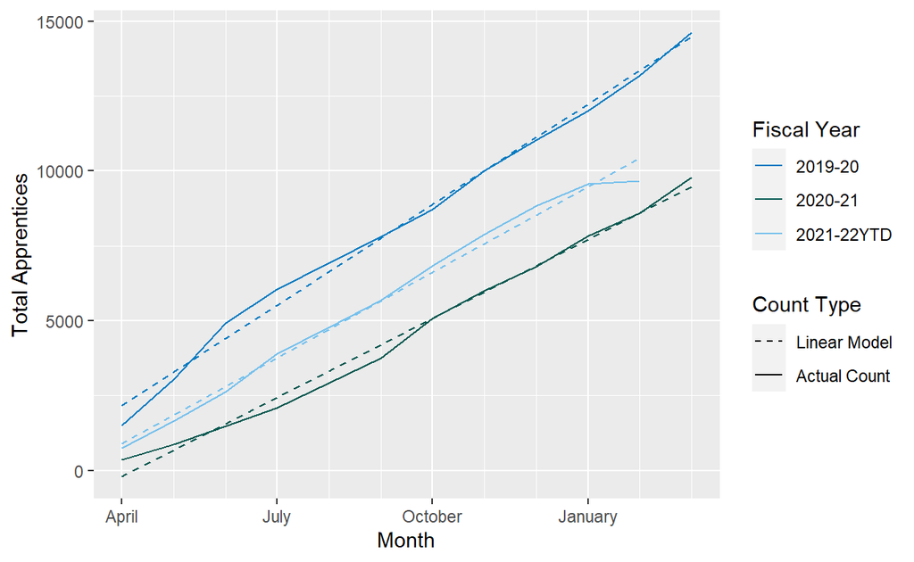

Figure 1: Cumulative Count of Survey-Eligible Apprentices

Linear models were created for each stratum, predicting the number of apprentices exiting in February and March 2022 by continuing the trend found in the previous 10 months of data. The resulting projected total number of apprentices for the current fiscal year is plotted in Figure 2 .

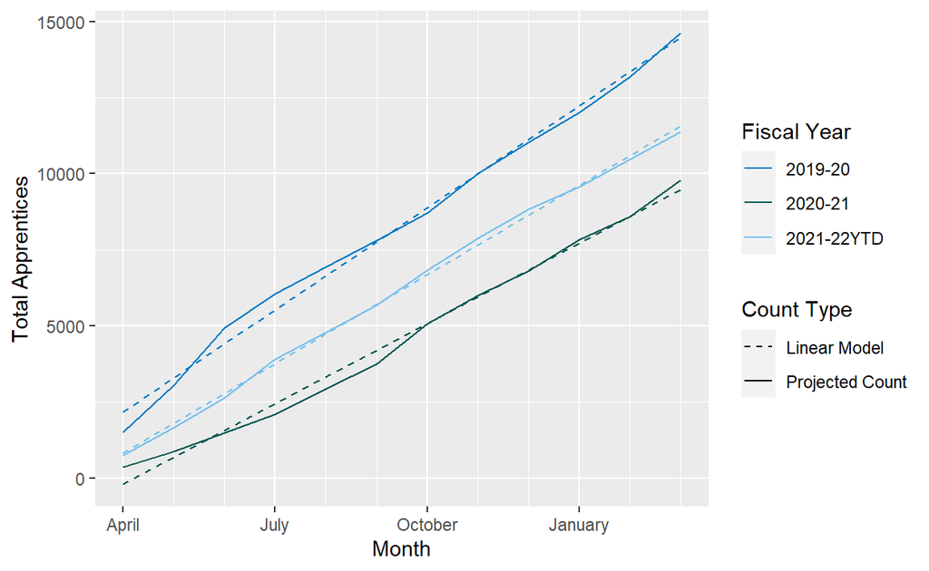

Figure 2: Cumulative Apprentice Exits with 2022 Projections

The resulting projections add up to a projected survey population of 11,377 people in fiscal year 2021-22.

## Sample Size Calculation

### Replication of ITQ Sample Size Calculation

An attempt was made to replicate the sample size calculation performed to support the ITQ. This attempt proved unsuccessful.

Analysis of the ITQ calculations revealed that the sample size was calculated based on stratification by region only. When these calculations were replicated for the projected 2021-22 population, they led to a sample size of 1,586. This number is *higher* than the sample size calculated for the larger population that was sampled for the ITQ. This in turn suggests an oversight in the ITQ calculations.

This was confirmed by replicating the calculations using full stratification by region, sector, and status. This calculation produced a sample size of 415, which is clearly too low.

The oversight may have been caused by using each stratum’s relative size in the population in place of the mean value of the survey question responses in the sample size formula. The ITQ formula was again applied to the projected 2021-22 data, but with a conservative estimate for survey question response value. The result was a sample size of 2,278. This sample size is likely too large to be practical, and its calculation may not resolve the oversight in the original ITQ’s calculations. The use of this sample size is thus not recommended.

### New Calculations for Sample Size

Two broad methods for sample size calculation were considered:

1. Stratification before sampling: treating each stratum as a population to be sampled
2. Sampling before stratification: calculating a sample size for the full population, then dividing that sample proportionally into each stratum

These methods are considered below.

#### Stratification Before Sampling

Projected apprentice data were stratified by region, sector, and status, and each stratum was treated as a separate population. Two formulas for sample size were then applied to each stratum: Cochran’s formula with modification for small sample sizes, and Yamane’s formula.

Both formulas led to impractically large sample sizes. Cochran’s formula determined a sample size of 7,373, or 65% of the total population. Yamane’s formula determined a similar sample size, at 7,461, or 66% of the total population.

Due to the impracticality of these sample sizes, the stratification-before-sampling approach is not recommended.

#### Sampling Before Stratification

Cochran’s and Yamane’s formulas were applied to the total projected survey population of apprentices. Cochran’s formula determined a sample size of 975, or 8.6% of the total population. Yamane’s formula determined a similar sample size, at 1,012, or 8.9% of the total population. Both of these formulas produce reasonable sample sizes.

Due to the uncertainties involved in projection, and for ease of communication, a slightly more conservative sample size of 10% of the population (and thus 10% of each stratum) can be reasonably proposed.

#### Sampling Before Stratification with Strata Miminums

A minimum sample size for all strata can be requested. This will increase confidence in the analysis of small strata. It will also reduce or eliminate the data suppression required to preserve apprentices’ privacy.

If 10% of the final population is sampled, the strata listed in Table 1 below will have projected sample sizes smaller than 10.

Table 1: Sample Sizes for Small Strata

| Region | Sector | Status | Apprentices | Sample Size |
| --- | --- | --- | --- | --- |
| Eastern | INDUST | CAN | 63 | 6 |
| Eastern | SERVC | CAN | 49 | 4 |
| Northern | INDUST | CAN | 66 | 6 |
| Northern | SERVC | CAN | 42 | 4 |
| Northern | SERVC | COMP | 78 | 7 |

If each of these strata have their sample size rounded up to 10, this will add only 23 people to the total sample. This suggests that requesting a minimum sample size of 10 for each stratum is reasonable.

## Conclusion

A sample of 10% of the apprentices in each stratum will lead to 95% confidence that the sample is representative, with a margin of error of 3%. A requirement for each stratum sample to include at least 10 responses will improve the analysis results while adding only a small number of additional apprentices to the overall sample. This strategy projects an overall sample size of approximately 1,144 apprentices.

## Appendix: Detailed Stratum Projections

Table 2 shows the projected number of apprentices with each combination of region, sector, and completion status. It also includes the sample sizes used in calculating the total of 1,144 apprentices.

Table 2: Projected Sample Sizes for All Strata

| Region | Sector | Status | Projected Apprentices | Sample Size |
| --- | --- | --- | --- | --- |
| Central | AUTO | CAN | 297 | 29 |
| Central | AUTO | COMP | 627 | 62 |
| Central | CONSTR | CAN | 636 | 63 |
| Central | CONSTR | COMP | 1526 | 152 |
| Central | INDUST | CAN | 105 | 10 |
| Central | INDUST | COMP | 317 | 31 |
| Central | SERVC | CAN | 116 | 11 |
| Central | SERVC | COMP | 502 | 50 |
| Eastern | AUTO | CAN | 128 | 12 |
| Eastern | AUTO | COMP | 267 | 26 |
| Eastern | CONSTR | CAN | 334 | 33 |
| Eastern | CONSTR | COMP | 652 | 65 |
| Eastern | INDUST | CAN | 63 | 10 |
| Eastern | INDUST | COMP | 111 | 11 |
| Eastern | SERVC | CAN | 49 | 10 |
| Eastern | SERVC | COMP | 188 | 18 |
| Northern | AUTO | CAN | 106 | 10 |
| Northern | AUTO | COMP | 183 | 18 |
| Northern | CONSTR | CAN | 159 | 15 |
| Northern | CONSTR | COMP | 263 | 26 |
| Northern | INDUST | CAN | 66 | 10 |
| Northern | INDUST | COMP | 144 | 14 |
| Northern | SERVC | CAN | 42 | 10 |
| Northern | SERVC | COMP | 78 | 10 |
| Western | AUTO | CAN | 280 | 28 |
| Western | AUTO | COMP | 573 | 57 |
| Western | CONSTR | CAN | 594 | 59 |
| Western | CONSTR | COMP | 1445 | 144 |
| Western | INDUST | CAN | 335 | 33 |
| Western | INDUST | COMP | 638 | 63 |
| Western | SERVC | CAN | 165 | 16 |
| Western | SERVC | COMP | 388 | 38 |
| Total | - | - | 11377 | 1144 |